# R PROJECT

Thomas Clamagirand - Dan Cemachovic - Gaëtan Brison - Selma Benlouhidy

15/12/2019

# I - Pratical problem

Predict if a person involved in a road accident is heavily injured or dead using the caracteristics of the accidents.

The dataset comes from the French government database (https://www.data.gouv.fr/fr/datasets/base-de-donnees-accidents-corporels-de-la-circulation) For the purpose of our project, we will focus only on July 2018 accidents.

# II - Mathematical problem

The problem is to explain the Y variable (binary variable stating if the person involved in the accident is injured/dead or not) by the other variables.

$$Y=\left\{
\begin{array}{ll}
1 & \text{if the person involved is hospitalised or dead} \\
0 & \text{otherwise}
\end{array}\right.$$

$$col=\text{type of collision}\quad col=\left\{\begin{array}{ll}
1 & \text{two vehicles frontal} \\
2 & \text{two vehicles from behind } \\
3 & \text{two vehicles from the side} \\
4 & \text{three vehicles or more - in a row} \\
5 & \text{three vehicles or more -multiple collision } \\
6 & \text{other collision } \\
7 & \text{without collision}
\end{array}\right.$$

$$int=\text{type of intersection}\quad int=\left\{\begin{array}{ll}
1 & \text{off intersection} \\
2 & \text{X intersection } \\
3 & \text{T intersection} \\
4 & \text{Y intersection} \\
5 & \text{Intersection with more than 4 roads } \\
6 & \text{oroundabout} \\
7 & \text{square} \\
8 & \text{railroad crossing} \\
9 & \text{other intersection}
\end{array}\right.$$

$$atm=\text{atmospheric conditions}\quad atm=\left\{\begin{array}{ll}
1 & \text{normal} \\
2 & \text{light rain } \\
3 & \text{heavy rain} \\
4 & \text{snow} \\
5 & \text{fog} \\
6 & \text{heavy wind} \\
7 & \text{very sunny} \\
8 & \text{cloudy weather} \\
9 & \text{other}
\end{array}\right.$$

$$catr=\text{road category}\quad catr=\left\{\begin{array}{ll}
1 & \text{Highway} \\
2 & \text{national road } \\
3 & \text{departmental road} \\
4 & \text{communal road} \\
5 & \text{outside public track} \\
6 & \text{parking lot} \\
9 & \text{other} \\
\end{array}\right.$$

$$catv2=\text{vehicle category}\quad catv2=\left\{\begin{array}{ll}
1 & \text{light vehicle} \\
2 & \text{truck } \\
3 & \text{scooter} \\
4 & \text{bike} \\
5 & \text{other} \\
\end{array}\right.$$

$$choc=\text{initial impact position}\quad choc=\left\{\begin{array}{ll}
1 & \text{front} \\
2 & \text{front-right} \\
3 & \text{front-left} \\
4 & \text{back} \\
5 & \text{back-right} \\
6 & \text{back-left} \\
7 & \text{right side} \\
8 & \text{left side} \\
9 & \text{multiple impacts}
\end{array}\right.$$

$$sexe=\text{sex of the user}\quad sexe=\left\{\begin{array}{ll}
1 & \text{male} \\
2 & \text{female} \\
\end{array}\right.$$

$$age=\text{age of the user}$$
$$hour-period=\text{Time of the accident}\quad hour-period=\left\{\begin{array}{ll}
1 & \text{Between 0:00 and 4:00 Am} \\
2 & \text{Between 4:00 and 8:00 Am} \\
3 & \text{Between 8:00 and 12:00 Am} \\
4 & \text{Between 12:00 and 16:00 Pm} \\
5 & \text{Between 16:00 and 20:00 Pm} \\
6 & \text{Between 20:00 and 24:00 Pm} \\
\end{array}\right.$$

$$day-number=\text{Day of the accident}\quad day-number=\left\{\begin{array}{ll}
1 & \text{Monday} \\
2 & \text{Tuesday} \\
3 & \text{Wednesday} \\
4 & \text{Thursday} \\
5 & \text{Friday} \\
6 & \text{Saturday} \\
7 & \text{Sunday} \\
\end{array}\right.$$

$$place=\text{seat number}\quad driver=\left\{\begin{array}{ll}
1 & \text{driver} \\
2:9 & \text{passenger} \\
\end{array}\right.$$

We need the following packages :

```r
library(tidyverse)
library(dplyr)
library(ggplot2)
library(sf)
library(glmnet)
library(caret)
library(pROC)
library(plotROC)
library(ranger)
library(Amelia)
library(leaflet)
library(leaps)
```

# III - Database Creation and Clean-up.

```r
#data import
caracteristiques=read.csv('caracteristiques-2018.csv',na.strings=c('NA',''))
lieux=read.csv('lieux-2018.csv',na.strings=c('NA',''))
usagers=read.csv('usagers-2018.csv',na.strings=c('NA',''))
vehicules=read.csv('vehicules-2018.csv',na.strings=c('NA',''))

#merging data
data1=left_join(caracteristiques,lieux,by=c('Num_Acc'='Num_Acc'))
data2=left_join(usagers,vehicules,by=c('Num_Acc'='Num_Acc','num_veh'='num_veh'))
data=left_join(data2,data1,by=c('Num_Acc'='Num_Acc'))


#filter on mainland france
data = data %>% filter(dep < 970) #exclusion territoire d'outre mer


#create the output variable : if user hospitalized or dead = 1, else = 0
data = data %>% mutate(Y = ifelse(between(grav,2,3),1,0)) %>% select(-grav)


#create age column
data = data %>% mutate(age=2018-an_nais) %>% select(-an_nais)

#transform hour into a period
data=data %>% mutate(hour_period=ifelse(between(hrmn,0,399),1,
                                   ifelse(between(hrmn,400,799),2,
                                            ifelse(between(hrmn,800,1199),3,
                                               ifelse(between(hrmn,1200,1599),4,
                                                  ifelse(between(hrmn,1600,1999),5,
                                                      ifelse(between(hrmn,2000,2399),6,0))))))) %>% select(-hrmn)

#create day of the week number columns and filtering on July
data = data %>%
  mutate(jour = ifelse(nchar(jour)==1,paste("0",jour,sep=""),jour),
         mois = ifelse(nchar(mois)==1,paste("0",mois,sep=""),mois)) %>%
  unite("date",c(jour,mois,an),sep="/")

data = data %>%
  mutate(date = as.Date(date,format = "%d/%m/%y"),
         day_number = strftime(data$date,format = '%u'),
         month_number = strftime(data$date,format = '%m')) %>%
  filter(month_number=="07") %>%
  select(-date)


#synthesize car category
data = data %>% mutate(catv2 = ifelse(catv == 7,1,
                                      ifelse(between(catv,13,15),2,
                                             ifelse(catv %in% c(2,5,4,31,32,33,34),3,
                                                    ifelse(catv == 1,4,5))))) %>%
  select(-catv)

#select only relevant columns
data = data %>% select(Y,col,int,atm,catr,catv2,choc,sexe,age,hour_period,day_number,place,dep,lat,long)

#make categorical variables
data$sexe=as.factor(data$sexe)
data$catv2=as.factor(data$catv2)
data$choc=as.factor(data$choc)
data$int=as.factor(data$int)
data$atm=as.factor(data$atm)
data$col=as.factor(data$col)
data$catr=as.factor(data$catr)
data$hour_period=as.factor(data$hour_period)
data$day_number=as.factor(data$day_number)
data$place = as.factor(data$place)
```

## Check missingness in data

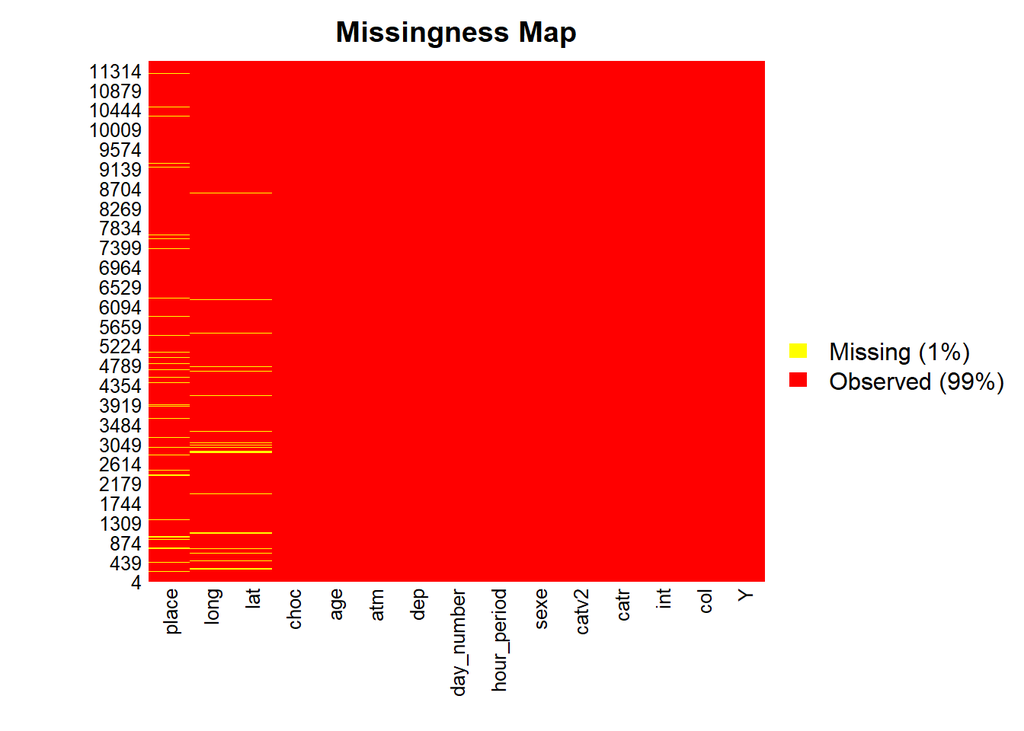

```r
missmap(data,col=c('yellow','red'))
```

Almost no missing values in the dataset (around 1%)

# IV - Data visualization

## Map of the number of deaths and injured per region

```r
#polygon data of regions
mymap = st_read("departements-20140306-100m.shx")
```

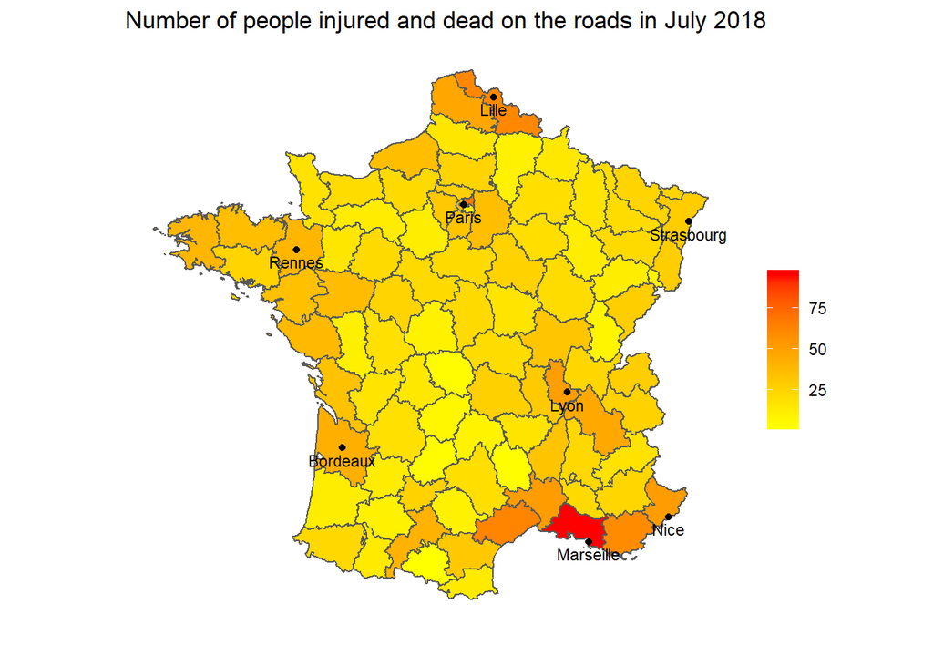

```r
#creation of data frame of number of deaths by region
data2 = data %>%
  filter(Y==1) %>%
  group_by(dep) %>%
  summarize(deaths = n()) %>%
  ungroup() %>%
  mutate(code = round(dep/10)) %>%
  mutate(code2 = ifelse(nchar(code)==1,paste("0",code,sep=""),code)) %>%
  select(-code,-dep)

colnames(data2)[2]="code_insee"
map_and_data = inner_join(mymap,data2)

#Main cities coordinates
city = c("Lille","Paris","Nice","Lyon","Bordeaux","Marseille","Rennes","Strasbourg")
x = c(3.058033,2.349332,7.280967,4.837865,-0.575843,5.355769,-1.676782,7.755226)
y = c(50.630564,48.858245,43.701432,45.757695,44.841802,43.287803,48.110294,48.577270)
points = data.frame(city,x,y)

ggplot(map_and_data) +
  geom_sf(aes(fill=deaths)) +
  scale_fill_continuous(low="yellow",high="red") +
  theme_bw() +
  ggtitle("Number of people injured and dead on the roads in July 2018") +
  theme(axis.text = element_blank(),
        axis.ticks.x = element_blank(),
        axis.ticks.y = element_blank(),
        panel.border = element_blank(),
        panel.grid.major = element_blank(),
        panel.grid.minor = element_blank()) +
  geom_point(data = points,aes(y=y,x=x)) +
  geom_text(data=points,aes(y=y - 0.2,x=x,label=city),size=3) +
  labs(x="",y="",fill = "")
```

## Histogram of the top 5 regions with the most deaths/injured in July 2018

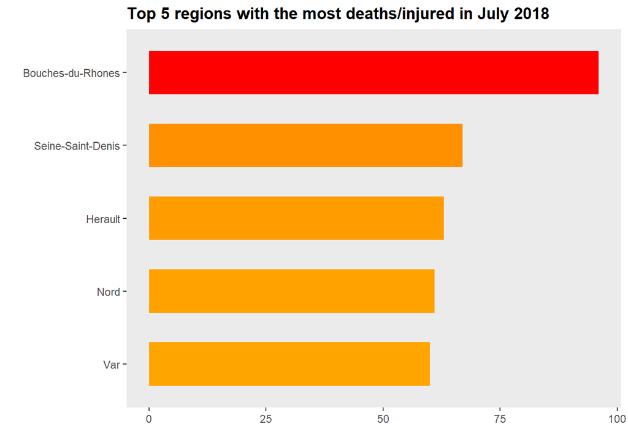

```r
data_histogram = data.frame(dep = map_and_data$nom,deaths = map_and_data$deaths)
top5 = data_histogram %>% arrange(desc(deaths)) %>% slice(1:5)

top5$dep = as.character(top5$dep)
top5[1,1] = "Bouches-du-Rhones"
top5[3,1] = "Herault"

ggplot(top5) +
  aes(x=reorder(dep,deaths),y=deaths,fill=deaths) +
  geom_bar(stat='identity',show.legend = FALSE,width = 0.6) +
  coord_flip() +
  ggtitle("Top 5 regions with the most deaths/injured in July 2018") +
  scale_fill_continuous(low="orange",high="red") +
  labs(x="",y="") +
  theme(plot.title = element_text(face="bold"),
        panel.border = element_blank(),
        panel.grid.major = element_blank(),
        panel.grid.minor = element_blank())
```

## Histogram of the bottom 5 regions of the most deaths/injured in July 2018.

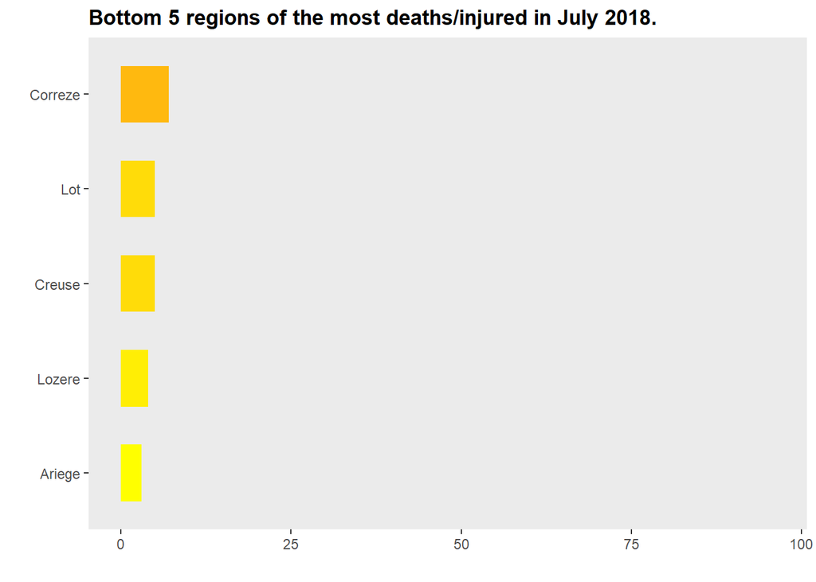

```r
bottom5 = data_histogram %>% arrange(deaths) %>% slice(1:5)

bottom5$dep = as.character(bottom5$dep)
bottom5[2,1] = "Lozere"
bottom5[1,1] = "Ariege"
bottom5[5,1] = "Correze"

ggplot(bottom5) +
  aes(x=reorder(dep,deaths),y=deaths,fill=deaths) +
  geom_bar(stat='identity',show.legend = FALSE,width = 0.6) +
  ggtitle("Bottom 5 regions of the most deaths/injured in July 2018.") +
  scale_fill_continuous(low="yellow",high="darkgoldenrod1") +
  labs(x="",y="") +
  theme(plot.title = element_text(face="bold"),
        panel.border = element_blank(),
        panel.grid.major = element_blank(),
        panel.grid.minor = element_blank()) +
  coord_flip(ylim=c(0,max(top5$deaths)))
```

## Interactive map displaying the concentration and exact localization of accidents

```r
ndata= data%>%mutate(lat=lat/100000,long=long/100000)
ndata=ndata%>%filter(long<=9.90000)

plot2=leaflet(data = ndata) %>% addTiles(urlTemplate = "http://{s}.tile.openstreetmap.org/{z}/{x}/{y}.png") %>%
  addCircleMarkers(~long, ~lat,radius=5,stroke=FALSE,fillOpacity=1.5,popup=~Y,clusterOptions = markerClusterOptions())
plot2
```

[interactive chart not shown]

## Lolipop graph for the number of deaths/injured per day on July

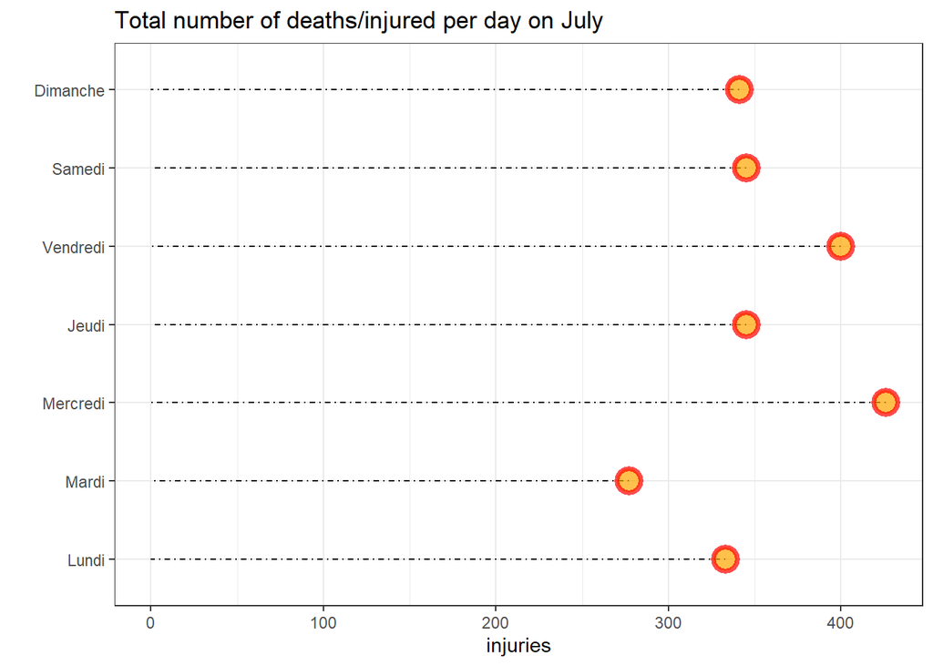

```r
day_bar_data = data %>% group_by(day_number) %>% summarize(injuries = sum(Y))

ggplot(day_bar_data) + aes(x=day_number,y=injuries,fill = injuries) +
    geom_segment( aes(xend=day_number, yend=0), linetype="dotdash")+
  scale_x_discrete(name = "",labels = c("Lundi","Mardi","Mercredi","Jeudi","Vendredi","Samedi","Dimanche")) +
    geom_point( size=5,color="red", fill=alpha("orange", 0.3), alpha=0.7, shape=21, stroke=2) +
    coord_flip() +
    theme_bw() +
    xlab("") +
    labs( title ="Total number of deaths/injured per day on July",ylab = '')
```

## Distribution of accidents per age and sexe of driver.

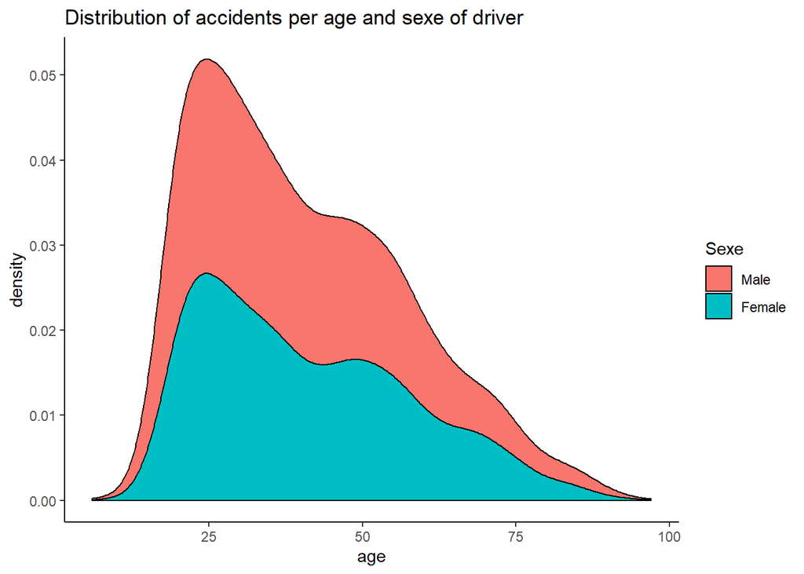

```r
ggplot(na.omit(data) %>% filter(place==1)) + aes(age,fill=sexe) +
  geom_density(position = "stack") +
  theme_classic() +
  scale_fill_discrete(name = "Sexe",labels = c("Male","Female")) +
  labs(title = 'Distribution of accidents per age and sexe of driver')
```

## Histogram of the number of people injured and dead on the roads by time period.

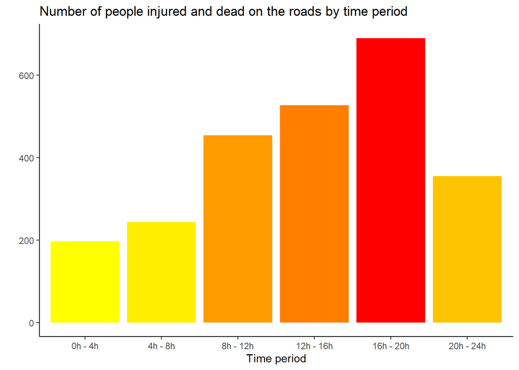

```r
hour_period_graph = data %>% group_by(hour_period) %>% summarize(number_injured = sum(Y))

ggplot(hour_period_graph) + aes(x=hour_period,y=number_injured,fill = number_injured) +
  geom_bar(stat="identity",show.legend=FALSE) +
  scale_x_discrete(name = "Time period",labels = c("0h - 4h","4h - 8h","8h - 12h","12h - 16h","16h - 20h","20h - 24h")) +
  theme_classic() +
  labs(y="", title ="Number of people injured and dead on the roads by time period") +
  scale_fill_continuous(low="yellow",high="red")
```

# V - Data exploration

## Logistic model with all the variables

We perform a logistic model on a train dataset with the following split:  
- a training set of 70% of the data  
- a test set of 30%.

```r
set.seed(1234)

data_ML = data %>% select(Y,col,int,atm,catr,catv2,choc,sexe,age,hour_period,day_number,place)

data_ML = na.omit(data_ML)
n= nrow(data_ML)

perm <- sample(n)
train <- data_ML[perm[1:round(n*0.7)],]
test <- data_ML[perm[round(n*0.7):n],]

train.X <- model.matrix(Y~.,data=train)
test.X <- model.matrix(Y~.,data=test)
full.logit <- glm(Y~.,data=train,family="binomial")

summary(full.logit)
```

```
##
## Call:
## glm(formula = Y ~ ., family = "binomial", data = train)
##
## Deviance Residuals:
##     Min       1Q   Median       3Q      Max
## -1.8984  -0.6495  -0.3998  -0.2010   3.0151
##
## Coefficients:
##                Estimate Std. Error z value Pr(>|z|)
## (Intercept)   -1.351626   0.245412  -5.508 3.64e-08 ***
## col2          -1.056321   0.143648  -7.354 1.93e-13 ***
## col3          -0.758495   0.109714  -6.913 4.73e-12 ***
## col4          -1.336070   0.212490  -6.288 3.22e-10 ***
## col5          -0.711786   0.154104  -4.619 3.86e-06 ***
## col6           0.065048   0.105665   0.616 0.538156
## col7           0.168533   0.144937   1.163 0.244912
## int2           0.057677   0.112441   0.513 0.607984
## int3          -0.254671   0.122193  -2.084 0.037145 *
## int4          -0.592156   0.253763  -2.333 0.019622 *
## int5          -1.112762   0.571538  -1.947 0.051539 .
## int6          -0.453868   0.194504  -2.333 0.019624 *
## int7          -2.236003   1.030708  -2.169 0.030053 *
## int8          -1.037576   1.092779  -0.949 0.342375
## int9           0.008516   0.169125   0.050 0.959842
## atm2          -0.105783   0.214711  -0.493 0.622241
## atm3          -0.185654   0.404309  -0.459 0.646099
## atm4         -11.905843 224.262208  -0.053 0.957661
## atm5          -0.363509   1.234677  -0.294 0.768440
## atm6         -10.821778 229.599512  -0.047 0.962407
## atm7           0.339270   0.163873   2.070 0.038422 *
## atm8           0.231753   0.320882   0.722 0.470149
## atm9           0.188107   0.748706   0.251 0.801627
## catr2          0.399139   0.158819   2.513 0.011965 *
## catr3          0.589291   0.117410   5.019 5.19e-07 ***
## catr4         -0.765592   0.127069  -6.025 1.69e-09 ***
## catr5         -0.487560   1.101325  -0.443 0.657980
## catr6         -0.563781   0.669837  -0.842 0.399973
## catr7         -0.617731   0.399531  -1.546 0.122071
## catr9         -1.252413   0.522519  -2.397 0.016535 *
```

[output cut: 29 more lines]

```
## place5        -0.357881   0.501251  -0.714 0.475243
## place6         0.833250   0.691886   1.204 0.228467
## place7         0.370282   0.256393   1.444 0.148684
## place8        -0.034946   0.423452  -0.083 0.934228
## place9         0.054470   0.276870   0.197 0.844035
## ---
## Signif. codes:  0 '***' 0.001 '**' 0.01 '*' 0.05 '.' 0.1 ' ' 1
##
## (Dispersion parameter for binomial family taken to be 1)
##
##     Null deviance: 7729.9  on 7537  degrees of freedom
## Residual deviance: 6199.3  on 7474  degrees of freedom
## AIC: 6327.3
##
## Number of Fisher Scoring iterations: 11
```

There are many noisy variables that are not significant.

## Variable selection

We propose to make a variable selection procedure with a backward selection approach using BIC criterion in order to understand better which variables are significant.

```r
mod.back <- step(full.logit,direction="backward",k=log(nrow(train)),trace=0)
summary(mod.back)
```

```
##
## Call:
## glm(formula = Y ~ col + catr + catv2 + age + hour_period, family = "binomial",
##     data = train)
##
## Deviance Residuals:
##     Min       1Q   Median       3Q      Max
## -1.8761  -0.6374  -0.4254  -0.2300   2.8071
##
## Coefficients:
##               Estimate Std. Error z value Pr(>|z|)
## (Intercept)  -1.344459   0.179625  -7.485 7.16e-14 ***
## col2         -1.292594   0.131226  -9.850  < 2e-16 ***
## col3         -0.878580   0.099634  -8.818  < 2e-16 ***
## col4         -1.585182   0.199602  -7.942 1.99e-15 ***
## col5         -0.790153   0.149804  -5.275 1.33e-07 ***
## col6          0.075052   0.101884   0.737   0.4613
## col7          0.272322   0.128363   2.121   0.0339 *
## catr2         0.356246   0.156230   2.280   0.0226 *
## catr3         0.538859   0.113913   4.730 2.24e-06 ***
## catr4        -0.862330   0.122852  -7.019 2.23e-12 ***
## catr5        -0.668462   1.093363  -0.611   0.5409
## catr6        -0.889261   0.651532  -1.365   0.1723
## catr7        -0.646959   0.395699  -1.635   0.1021
## catr9        -1.299096   0.513108  -2.532   0.0113 *
## catv22       -0.777731   0.316049  -2.461   0.0139 *
## catv23        1.692205   0.077800  21.751  < 2e-16 ***
## catv24        1.804255   0.131006  13.772  < 2e-16 ***
## catv25        0.127526   0.110897   1.150   0.2502
## age           0.010720   0.001754   6.113 9.80e-10 ***
## hour_period2  0.112542   0.152396   0.738   0.4602
## hour_period3 -0.589681   0.139494  -4.227 2.37e-05 ***
## hour_period4 -0.581020   0.134789  -4.311 1.63e-05 ***
## hour_period5 -0.546468   0.129785  -4.211 2.55e-05 ***
## hour_period6 -0.158996   0.139608  -1.139   0.2548
## ---
## Signif. codes:  0 '***' 0.001 '**' 0.01 '*' 0.05 '.' 0.1 ' ' 1
##
## (Dispersion parameter for binomial family taken to be 1)
##
##     Null deviance: 7729.9  on 7537  degrees of freedom
## Residual deviance: 6321.4  on 7514  degrees of freedom
## AIC: 6369.4
##
## Number of Fisher Scoring iterations: 5
```

There are many variables significant, conditioned on the intercept.

The intercept is made of : two vehicules in a frontal collision on a highway, off intersetion, with normal atmospheric conditions, with a light vehicle, with an initial impact on the front, with a Male user driving between 0 and 4am on Monday.

It is hard to interpret clearly the coefficient because of the high dimension. For the analysis of coefficients, we have to assume each time that only one coefficient changes and all other intercept coefficients remain equal.

# VI - Machine Learning

We make a 10-K cross validation, training and testing 10 times five different methods : Ridge, Lasso, Random Forest, Full logistic model, Backward logistic model.

```r
set.seed(1234)

data_ML_X = model.matrix(Y~.,data=data_ML)[,-1]
data_ML_Y = as.numeric(data_ML[,'Y'])


folds <- createFolds(1:nrow(data_ML),k=10,returnTrain = FALSE)
prev_AUC = matrix(0,nrow=nrow(data_ML),ncol=5) %>% as.data.frame()
prev_Error = matrix(0,nrow=nrow(data_ML),ncol=5) %>% as.data.frame()
names(prev_AUC) = c('ridge','lasso','forest','full','back')
names(prev_Error) = c('ridge','lasso','forest','full','back')

for (k in 1:10){
  train.X = data_ML_X[-folds[[k]],]
  test.X = data_ML_X[folds[[k]],]
  train.Y = data_ML_Y[-folds[[k]]]

  train = data_ML %>% slice(-folds[[k]])
  test = data_ML %>% slice(folds[[k]])

  ridge.cv = cv.glmnet(train.X,train.Y,alpha = 0,family="binomial",lambda = exp(seq(-8,4,length=100)))
  lasso.cv = cv.glmnet(train.X,train.Y,alpha = 1,family="binomial",lambda = exp(seq(-8,4,length=100)))
  forest.cv = ranger(Y~.,data=train,probability = TRUE)
  full.logit <- glm(Y~.,data=train,family="binomial")
  mod.back <- step(full.logit,direction="backward",k=log(nrow(train)),trace=0)

  prev_AUC[folds[[k]],1] = as.vector(predict(ridge.cv,newx=test.X,type='response'))
  prev_AUC[folds[[k]],2] = as.vector(predict(lasso.cv,newx=test.X,type='response'))
  prev_AUC[folds[[k]],3] = predict(forest.cv,data = test)[1]$predictions[,2]
  prev_AUC[folds[[k]],4] = predict(full.logit,newdata=test,type="response")
  prev_AUC[folds[[k]],5] = predict(mod.back,newdata=test,type="response")

  prev_Error[folds[[k]],1] = predict(ridge.cv,newx=test.X,type='class',s="lambda.min")
  prev_Error[folds[[k]],2] = predict(lasso.cv,newx=test.X,type='class',s="lambda.min")
}
```

We make a comparison of the 5 methods with ROC curve and AUC (estimated on the test dataset).

```r
result_AUC = data.frame(prev_AUC,data_ML_Y)
prev1 = result_AUC %>% gather(key = "Method", value ="score",-data_ML_Y)

prev1 %>% group_by(Method) %>% summarize(AUC = auc(data_ML_Y,score)) %>% arrange(desc(AUC))
```

```
## # A tibble: 5 x 2
##   Method   AUC
##   <chr>  <dbl>
## 1 forest 0.810
## 2 full   0.795
## 3 back   0.794
## 4 ridge  0.792
## 5 lasso  0.791
```

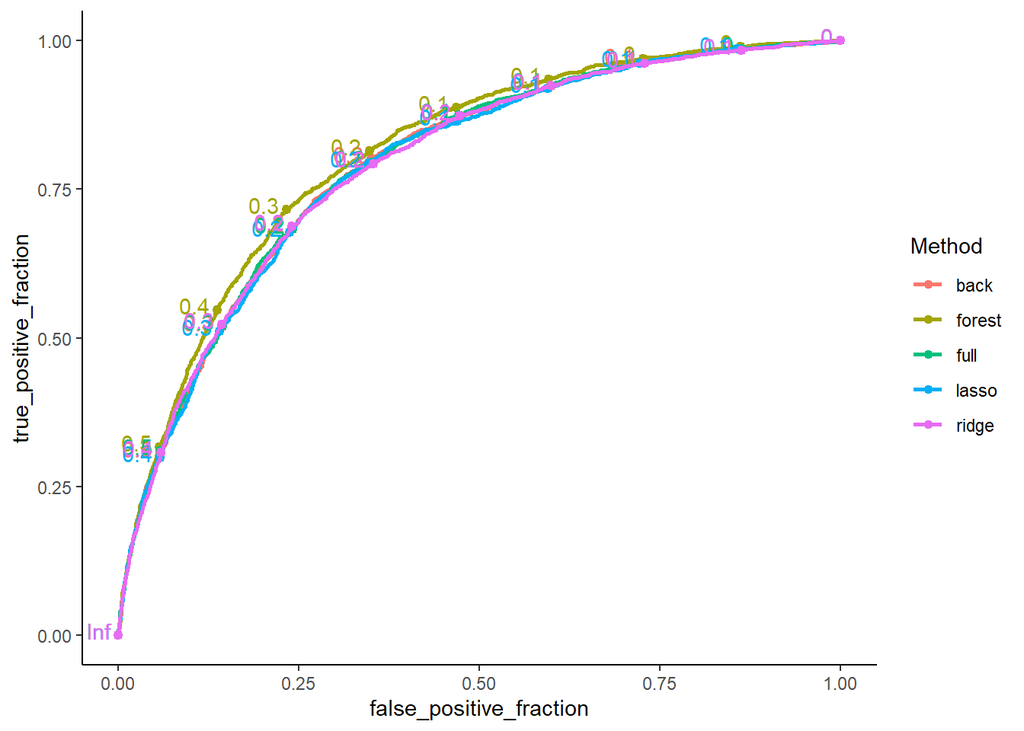

```r
ggplot(prev1) + aes(d=data_ML_Y,m=score,color=Method) + geom_roc() + theme_classic()
```

The random forest model has the highest AUC.

We make a comparison of the 5 methods with the error probability (estimated on the test dataset).

The risk is estimated with the test set according to

$$\frac{1}{n_{test}}\sum_{i\in test}(Y_i-\widehat m(X_i))^2.$$

```r
prev_Error[,3] = prev_Error[,3] %>% round() %>% as.factor()
prev_Error[,4] = prev_Error[,4] %>% round() %>% as.factor()
prev_Error[,5] = prev_Error[,5] %>% round() %>% as.factor()

prev = data.frame(prev_Error, data_ML_Y)

prev %>% summarise_at(vars(1:5),~(mean((.!=data_ML_Y)^2)))
```

```
##       ridge     lasso   forest     full     back
## 1 0.1867571 0.1856426 0.205052 0.205052 0.205052
```

Lasso has the smallest estimated quadratic error.